# Risk Factor Analysis

## Outcome Variable

**Outcome Variable:** sstunted

## Predictor Variables

**Intervention Variable:** tr

**Adjustment Set:**

unadjusted

## Stratifying Variables

The analysis was stratified on these variable(s):

- agecat
- studyid
- country
- intXpredexfd6

## Data Summary

| agecat | studyid | country | intXpredexfd6 | sstunted | n_cell | n |
| --- | --- | --- | --- | --- | --- | --- |
| Birth | ki1000304b-SAS-CompFeed | INDIA | 0_Birth | 0 | 1 | 1 |
| Birth | ki1000304b-SAS-CompFeed | INDIA | 0_Birth | 1 | 0 | 1 |
| Birth | ki1000304b-SAS-CompFeed | INDIA | 1_Birth | 0 | 35 | 36 |
| Birth | ki1000304b-SAS-CompFeed | INDIA | 1_Birth | 1 | 1 | 36 |
| Birth | kiGH5241-JiVitA-3 | BANGLADESH | 0_Birth | 0 | 6878 | 7972 |
| Birth | kiGH5241-JiVitA-3 | BANGLADESH | 0_Birth | 1 | 1094 | 7972 |
| Birth | kiGH5241-JiVitA-3 | BANGLADESH | 1_Birth | 0 | 27582 | 30192 |
| Birth | kiGH5241-JiVitA-3 | BANGLADESH | 1_Birth | 1 | 2610 | 30192 |
| Birth | kiGH5241-JiVitA-4 | BANGLADESH | 0_Birth | 0 | 264 | 296 |
| Birth | kiGH5241-JiVitA-4 | BANGLADESH | 0_Birth | 1 | 32 | 296 |
| Birth | kiGH5241-JiVitA-4 | BANGLADESH | 1_Birth | 0 | 1148 | 1238 |
| Birth | kiGH5241-JiVitA-4 | BANGLADESH | 1_Birth | 1 | 90 | 1238 |
| 6 months | iLiNS_DYADM_LNS | MALAWI | 0_6 months | 0 | 2 | 3 |
| 6 months | iLiNS_DYADM_LNS | MALAWI | 0_6 months | 1 | 1 | 3 |
| 6 months | iLiNS_DYADM_LNS | MALAWI | 1_6 months | 0 | 59 | 61 |
| 6 months | iLiNS_DYADM_LNS | MALAWI | 1_6 months | 1 | 2 | 61 |
| 6 months | ki1000304b-SAS-CompFeed | INDIA | 0_6 months | 0 | 14 | 14 |
| 6 months | ki1000304b-SAS-CompFeed | INDIA | 0_6 months | 1 | 0 | 14 |
| 6 months | ki1000304b-SAS-CompFeed | INDIA | 1_6 months | 0 | 233 | 257 |
| 6 months | ki1000304b-SAS-CompFeed | INDIA | 1_6 months | 1 | 24 | 257 |
| 6 months | ki1000304b-SAS-FoodSuppl | INDIA | 0_6 months | 0 | 133 | 160 |
| 6 months | ki1000304b-SAS-FoodSuppl | INDIA | 0_6 months | 1 | 27 | 160 |
| 6 months | ki1017093b-PROVIDE | BANGLADESH | 0_6 months | 0 | 18 | 18 |
| 6 months | ki1017093b-PROVIDE | BANGLADESH | 0_6 months | 1 | 0 | 18 |
| 6 months | ki1017093b-PROVIDE | BANGLADESH | 1_6 months | 0 | 27 | 28 |
| 6 months | ki1017093b-PROVIDE | BANGLADESH | 1_6 months | 1 | 1 | 28 |
| 6 months | ki1148112-iLiNS-DOSE | MALAWI | 0_6 months | 0 | 144 | 161 |
| 6 months | ki1148112-iLiNS-DOSE | MALAWI | 0_6 months | 1 | 17 | 161 |
| 6 months | ki1148112-iLiNS-DOSE | MALAWI | 1_6 months | 0 | 958 | 1014 |
| 6 months | ki1148112-iLiNS-DOSE | MALAWI | 1_6 months | 1 | 56 | 1014 |
| 6 months | ki1148112-iLiNS-DYAD-M | MALAWI | 0_6 months | 0 | 2 | 3 |
| 6 months | ki1148112-iLiNS-DYAD-M | MALAWI | 0_6 months | 1 | 1 | 3 |
| 6 months | ki1148112-iLiNS-DYAD-M | MALAWI | 1_6 months | 0 | 89 | 94 |
| 6 months | ki1148112-iLiNS-DYAD-M | MALAWI | 1_6 months | 1 | 5 | 94 |
| 6 months | ki1148112-LCNI-5 | MALAWI | 0_6 months | 0 | 208 | 225 |
| 6 months | ki1148112-LCNI-5 | MALAWI | 0_6 months | 1 | 17 | 225 |
| 6 months | ki1148112-LCNI-5 | MALAWI | 1_6 months | 0 | 44 | 47 |
| 6 months | ki1148112-LCNI-5 | MALAWI | 1_6 months | 1 | 3 | 47 |
| 6 months | kiGH5241-JiVitA-3 | BANGLADESH | 0_6 months | 0 | 6098 | 6848 |
| 6 months | kiGH5241-JiVitA-3 | BANGLADESH | 0_6 months | 1 | 750 | 6848 |
| 6 months | kiGH5241-JiVitA-3 | BANGLADESH | 1_6 months | 0 | 25170 | 26422 |
| 6 months | kiGH5241-JiVitA-3 | BANGLADESH | 1_6 months | 1 | 1252 | 26422 |
| 6 months | kiGH5241-JiVitA-4 | BANGLADESH | 0_6 months | 0 | 1616 | 1796 |
| 6 months | kiGH5241-JiVitA-4 | BANGLADESH | 0_6 months | 1 | 180 | 1796 |
| 6 months | kiGH5241-JiVitA-4 | BANGLADESH | 1_6 months | 0 | 6364 | 6656 |
| 6 months | kiGH5241-JiVitA-4 | BANGLADESH | 1_6 months | 1 | 292 | 6656 |
| 24 months | iLiNS_DYADM_LNS | MALAWI | 1_24 months | 0 | 6 | 7 |
| 24 months | iLiNS_DYADM_LNS | MALAWI | 1_24 months | 1 | 1 | 7 |
| 24 months | ki1017093b-PROVIDE | BANGLADESH | 0_24 months | 0 | 1 | 1 |
| 24 months | ki1017093b-PROVIDE | BANGLADESH | 0_24 months | 1 | 0 | 1 |
| 24 months | ki1017093b-PROVIDE | BANGLADESH | 1_24 months | 0 | 1 | 1 |
| 24 months | ki1017093b-PROVIDE | BANGLADESH | 1_24 months | 1 | 0 | 1 |
| 24 months | ki1148112-iLiNS-DOSE | MALAWI | 0_24 months | 0 | 50 | 59 |
| 24 months | ki1148112-iLiNS-DOSE | MALAWI | 0_24 months | 1 | 9 | 59 |
| 24 months | ki1148112-iLiNS-DOSE | MALAWI | 1_24 months | 0 | 347 | 442 |
| 24 months | ki1148112-iLiNS-DOSE | MALAWI | 1_24 months | 1 | 95 | 442 |
| 24 months | ki1148112-iLiNS-DYAD-M | MALAWI | 1_24 months | 0 | 10 | 12 |
| 24 months | ki1148112-iLiNS-DYAD-M | MALAWI | 1_24 months | 1 | 2 | 12 |
| 24 months | ki1148112-LCNI-5 | MALAWI | 0_24 months | 0 | 37 | 44 |
| 24 months | ki1148112-LCNI-5 | MALAWI | 0_24 months | 1 | 7 | 44 |
| 24 months | ki1148112-LCNI-5 | MALAWI | 1_24 months | 0 | 7 | 7 |
| 24 months | ki1148112-LCNI-5 | MALAWI | 1_24 months | 1 | 0 | 7 |
| 24 months | kiGH5241-JiVitA-3 | BANGLADESH | 0_24 months | 0 | 30 | 40 |
| 24 months | kiGH5241-JiVitA-3 | BANGLADESH | 0_24 months | 1 | 10 | 40 |
| 24 months | kiGH5241-JiVitA-3 | BANGLADESH | 1_24 months | 0 | 58 | 80 |
| 24 months | kiGH5241-JiVitA-3 | BANGLADESH | 1_24 months | 1 | 22 | 80 |
| 24 months | kiGH5241-JiVitA-4 | BANGLADESH | 0_24 months | 0 | 344 | 396 |
| 24 months | kiGH5241-JiVitA-4 | BANGLADESH | 0_24 months | 1 | 52 | 396 |
| 24 months | kiGH5241-JiVitA-4 | BANGLADESH | 1_24 months | 0 | 1216 | 1332 |
| 24 months | kiGH5241-JiVitA-4 | BANGLADESH | 1_24 months | 1 | 116 | 1332 |

The following strata were considered:

- agecat: 24 months, studyid: iLiNS_DYADM_LNS, country: MALAWI, intXpredexfd6: 1_24 months
- agecat: 24 months, studyid: ki1017093b-PROVIDE, country: BANGLADESH, intXpredexfd6: 0_24 months
- agecat: 24 months, studyid: ki1017093b-PROVIDE, country: BANGLADESH, intXpredexfd6: 1_24 months
- agecat: 24 months, studyid: ki1148112-iLiNS-DOSE, country: MALAWI, intXpredexfd6: 0_24 months
- agecat: 24 months, studyid: ki1148112-iLiNS-DOSE, country: MALAWI, intXpredexfd6: 1_24 months
- agecat: 24 months, studyid: ki1148112-iLiNS-DYAD-M, country: MALAWI, intXpredexfd6: 1_24 months
- agecat: 24 months, studyid: ki1148112-LCNI-5, country: MALAWI, intXpredexfd6: 0_24 months
- agecat: 24 months, studyid: ki1148112-LCNI-5, country: MALAWI, intXpredexfd6: 1_24 months
- agecat: 24 months, studyid: kiGH5241-JiVitA-3, country: BANGLADESH, intXpredexfd6: 0_24 months
- agecat: 24 months, studyid: kiGH5241-JiVitA-3, country: BANGLADESH, intXpredexfd6: 1_24 months
- agecat: 24 months, studyid: kiGH5241-JiVitA-4, country: BANGLADESH, intXpredexfd6: 0_24 months
- agecat: 24 months, studyid: kiGH5241-JiVitA-4, country: BANGLADESH, intXpredexfd6: 1_24 months
- agecat: 6 months, studyid: iLiNS_DYADM_LNS, country: MALAWI, intXpredexfd6: 0_6 months
- agecat: 6 months, studyid: iLiNS_DYADM_LNS, country: MALAWI, intXpredexfd6: 1_6 months
- agecat: 6 months, studyid: ki1000304b-SAS-CompFeed, country: INDIA, intXpredexfd6: 0_6 months
- agecat: 6 months, studyid: ki1000304b-SAS-CompFeed, country: INDIA, intXpredexfd6: 1_6 months
- agecat: 6 months, studyid: ki1000304b-SAS-FoodSuppl, country: INDIA, intXpredexfd6: 0_6 months
- agecat: 6 months, studyid: ki1017093b-PROVIDE, country: BANGLADESH, intXpredexfd6: 0_6 months
- agecat: 6 months, studyid: ki1017093b-PROVIDE, country: BANGLADESH, intXpredexfd6: 1_6 months
- agecat: 6 months, studyid: ki1148112-iLiNS-DOSE, country: MALAWI, intXpredexfd6: 0_6 months
- agecat: 6 months, studyid: ki1148112-iLiNS-DOSE, country: MALAWI, intXpredexfd6: 1_6 months
- agecat: 6 months, studyid: ki1148112-iLiNS-DYAD-M, country: MALAWI, intXpredexfd6: 0_6 months
- agecat: 6 months, studyid: ki1148112-iLiNS-DYAD-M, country: MALAWI, intXpredexfd6: 1_6 months
- agecat: 6 months, studyid: ki1148112-LCNI-5, country: MALAWI, intXpredexfd6: 0_6 months
- agecat: 6 months, studyid: ki1148112-LCNI-5, country: MALAWI, intXpredexfd6: 1_6 months
- agecat: 6 months, studyid: kiGH5241-JiVitA-3, country: BANGLADESH, intXpredexfd6: 0_6 months
- agecat: 6 months, studyid: kiGH5241-JiVitA-3, country: BANGLADESH, intXpredexfd6: 1_6 months
- agecat: 6 months, studyid: kiGH5241-JiVitA-4, country: BANGLADESH, intXpredexfd6: 0_6 months
- agecat: 6 months, studyid: kiGH5241-JiVitA-4, country: BANGLADESH, intXpredexfd6: 1_6 months
- agecat: Birth, studyid: ki1000304b-SAS-CompFeed, country: INDIA, intXpredexfd6: 0_Birth
- agecat: Birth, studyid: ki1000304b-SAS-CompFeed, country: INDIA, intXpredexfd6: 1_Birth
- agecat: Birth, studyid: kiGH5241-JiVitA-3, country: BANGLADESH, intXpredexfd6: 0_Birth
- agecat: Birth, studyid: kiGH5241-JiVitA-3, country: BANGLADESH, intXpredexfd6: 1_Birth
- agecat: Birth, studyid: kiGH5241-JiVitA-4, country: BANGLADESH, intXpredexfd6: 0_Birth
- agecat: Birth, studyid: kiGH5241-JiVitA-4, country: BANGLADESH, intXpredexfd6: 1_Birth

### Dropped Strata

Some strata were dropped due to rare outcomes:

- agecat: Birth, studyid: ki1000304b-SAS-CompFeed, country: INDIA, intXpredexfd6: 0_Birth
- agecat: Birth, studyid: ki1000304b-SAS-CompFeed, country: INDIA, intXpredexfd6: 1_Birth
- agecat: 6 months, studyid: iLiNS_DYADM_LNS, country: MALAWI, intXpredexfd6: 0_6 months
- agecat: 6 months, studyid: iLiNS_DYADM_LNS, country: MALAWI, intXpredexfd6: 1_6 months
- agecat: 6 months, studyid: ki1000304b-SAS-CompFeed, country: INDIA, intXpredexfd6: 0_6 months
- agecat: 6 months, studyid: ki1017093b-PROVIDE, country: BANGLADESH, intXpredexfd6: 0_6 months
- agecat: 6 months, studyid: ki1017093b-PROVIDE, country: BANGLADESH, intXpredexfd6: 1_6 months
- agecat: 6 months, studyid: ki1148112-iLiNS-DYAD-M, country: MALAWI, intXpredexfd6: 0_6 months
- agecat: 6 months, studyid: ki1148112-LCNI-5, country: MALAWI, intXpredexfd6: 1_6 months
- agecat: 24 months, studyid: iLiNS_DYADM_LNS, country: MALAWI, intXpredexfd6: 1_24 months
- agecat: 24 months, studyid: ki1017093b-PROVIDE, country: BANGLADESH, intXpredexfd6: 0_24 months
- agecat: 24 months, studyid: ki1017093b-PROVIDE, country: BANGLADESH, intXpredexfd6: 1_24 months
- agecat: 24 months, studyid: ki1148112-iLiNS-DYAD-M, country: MALAWI, intXpredexfd6: 1_24 months
- agecat: 24 months, studyid: ki1148112-LCNI-5, country: MALAWI, intXpredexfd6: 1_24 months

## Methods Detail

We’re interested in the causal parameters $E[Y_a]$ for all values of $a \in \mathcal{A}$. These parameters represent the mean outcome if, possibly contrary to fact, we intervened to set all units to have $A=a$. Under the randomization and positivity assumptions, these are identified by the statistical parameters $\psi_a=E_W[E_{Y|A,W}(Y|A=a,W)]$. In addition, we’re interested in the mean of $Y$, $E[Y]$ under no intervention (the observed mean). We will estimate these parameters by using SuperLearner to fit the relevant likelihood factors – $E_{Y|A,W}(Y|A=a,W)$ and $p(A=a|W)$, and then updating our likelihood fit using a joint TMLE.

For unadjusted analyses ($W=\{\}$), initial likelihoods were estimated using Lrnr_glm to estimate the simple $E(Y|A)$ and Lrnr_mean to estimate $p(A)$. For adjusted analyses, a small library containing Lrnr_glmnet, Lrnr_xgboost, and Lrnr_mean was used.

Having estimated these parameters, we will then use the delta method to estimate relative risks and attributable risks relative to a prespecified baseline level of $A$.

# Results Detail

## Results Plots

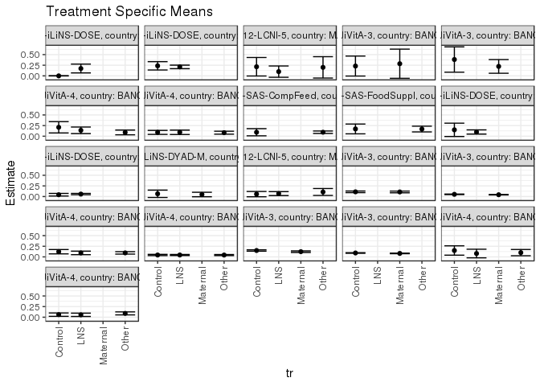

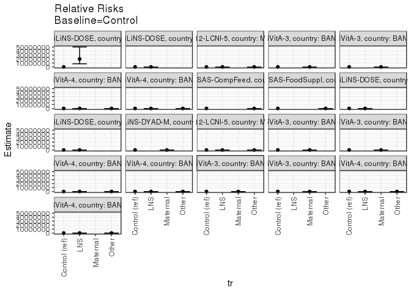

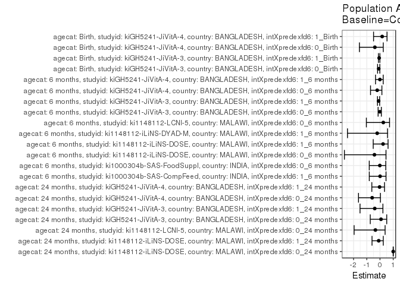

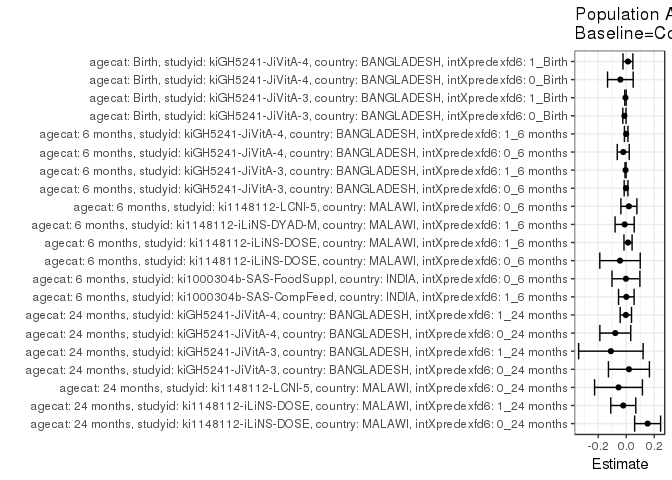

## Results Table

### Parameter: TSM

| agecat | studyid | country | intXpredexfd6 | intervention_level | baseline_level | estimate | ci_lower | ci_upper |
| --- | --- | --- | --- | --- | --- | --- | --- | --- |
| Birth | kiGH5241-JiVitA-3 | BANGLADESH | 0_Birth | Control | NA | 0.1501883 | 0.1343213 | 0.1660554 |
| Birth | kiGH5241-JiVitA-3 | BANGLADESH | 0_Birth | Maternal | NA | 0.1224490 | 0.1041948 | 0.1407032 |
| Birth | kiGH5241-JiVitA-3 | BANGLADESH | 1_Birth | Control | NA | 0.0918853 | 0.0851009 | 0.0986696 |
| Birth | kiGH5241-JiVitA-3 | BANGLADESH | 1_Birth | Maternal | NA | 0.0812767 | 0.0745867 | 0.0879666 |
| Birth | kiGH5241-JiVitA-4 | BANGLADESH | 0_Birth | Control | NA | 0.1500000 | 0.0402428 | 0.2597572 |
| Birth | kiGH5241-JiVitA-4 | BANGLADESH | 0_Birth | LNS | NA | 0.0789474 | -0.0223740 | 0.1802688 |
| Birth | kiGH5241-JiVitA-4 | BANGLADESH | 0_Birth | Other | NA | 0.1000000 | 0.0263159 | 0.1736841 |
| Birth | kiGH5241-JiVitA-4 | BANGLADESH | 1_Birth | Control | NA | 0.0606061 | 0.0206440 | 0.1005681 |
| Birth | kiGH5241-JiVitA-4 | BANGLADESH | 1_Birth | LNS | NA | 0.0568182 | 0.0177105 | 0.0959258 |
| Birth | kiGH5241-JiVitA-4 | BANGLADESH | 1_Birth | Other | NA | 0.0899281 | 0.0545855 | 0.1252707 |
| 6 months | ki1000304b-SAS-CompFeed | INDIA | 1_6 months | Control | NA | 0.0927835 | 0.0084390 | 0.1771280 |
| 6 months | ki1000304b-SAS-CompFeed | INDIA | 1_6 months | Other | NA | 0.0937500 | 0.0649045 | 0.1225955 |
| 6 months | ki1000304b-SAS-FoodSuppl | INDIA | 0_6 months | Control | NA | 0.1707317 | 0.0551944 | 0.2862690 |
| 6 months | ki1000304b-SAS-FoodSuppl | INDIA | 0_6 months | Other | NA | 0.1680672 | 0.1006732 | 0.2354613 |
| 6 months | ki1148112-iLiNS-DOSE | MALAWI | 0_6 months | Control | NA | 0.1500000 | -0.0069788 | 0.3069788 |
| 6 months | ki1148112-iLiNS-DOSE | MALAWI | 0_6 months | LNS | NA | 0.0992908 | 0.0497756 | 0.1488059 |
| 6 months | ki1148112-iLiNS-DOSE | MALAWI | 1_6 months | Control | NA | 0.0424242 | 0.0116552 | 0.0731933 |
| 6 months | ki1148112-iLiNS-DOSE | MALAWI | 1_6 months | LNS | NA | 0.0577150 | 0.0420206 | 0.0734093 |
| 6 months | ki1148112-iLiNS-DYAD-M | MALAWI | 1_6 months | Control | NA | 0.0645161 | -0.0224283 | 0.1514606 |
| 6 months | ki1148112-iLiNS-DYAD-M | MALAWI | 1_6 months | Maternal | NA | 0.0476190 | -0.0052493 | 0.1004874 |
| 6 months | ki1148112-LCNI-5 | MALAWI | 0_6 months | Control | NA | 0.0566038 | -0.0057478 | 0.1189553 |
| 6 months | ki1148112-LCNI-5 | MALAWI | 0_6 months | LNS | NA | 0.0689655 | 0.0227503 | 0.1151808 |
| 6 months | ki1148112-LCNI-5 | MALAWI | 0_6 months | Other | NA | 0.1071429 | 0.0259545 | 0.1883312 |
| 6 months | kiGH5241-JiVitA-3 | BANGLADESH | 0_6 months | Control | NA | 0.1108597 | 0.0917730 | 0.1299464 |
| 6 months | kiGH5241-JiVitA-3 | BANGLADESH | 0_6 months | Maternal | NA | 0.1080918 | 0.0879801 | 0.1282035 |
| 6 months | kiGH5241-JiVitA-3 | BANGLADESH | 1_6 months | Control | NA | 0.0524038 | 0.0467159 | 0.0580916 |
| 6 months | kiGH5241-JiVitA-3 | BANGLADESH | 1_6 months | Maternal | NA | 0.0425690 | 0.0376688 | 0.0474692 |
| 6 months | kiGH5241-JiVitA-4 | BANGLADESH | 0_6 months | Control | NA | 0.1214953 | 0.0706364 | 0.1723543 |
| 6 months | kiGH5241-JiVitA-4 | BANGLADESH | 0_6 months | LNS | NA | 0.0931174 | 0.0516047 | 0.1346301 |
| 6 months | kiGH5241-JiVitA-4 | BANGLADESH | 0_6 months | Other | NA | 0.0938215 | 0.0655315 | 0.1221116 |
| 6 months | kiGH5241-JiVitA-4 | BANGLADESH | 1_6 months | Control | NA | 0.0441860 | 0.0297954 | 0.0585767 |
| 6 months | kiGH5241-JiVitA-4 | BANGLADESH | 1_6 months | LNS | NA | 0.0444685 | 0.0320693 | 0.0568678 |
| 6 months | kiGH5241-JiVitA-4 | BANGLADESH | 1_6 months | Other | NA | 0.0433376 | 0.0310675 | 0.0556078 |
| 24 months | ki1148112-iLiNS-DOSE | MALAWI | 0_24 months | Control | NA | 0.0000000 | 0.0000000 | 0.0000000 |
| 24 months | ki1148112-iLiNS-DOSE | MALAWI | 0_24 months | LNS | NA | 0.1730769 | 0.0693693 | 0.2767845 |
| 24 months | ki1148112-iLiNS-DOSE | MALAWI | 1_24 months | Control | NA | 0.2361111 | 0.1379031 | 0.3343191 |
| 24 months | ki1148112-iLiNS-DOSE | MALAWI | 1_24 months | LNS | NA | 0.2108108 | 0.1692029 | 0.2524187 |
| 24 months | ki1148112-LCNI-5 | MALAWI | 0_24 months | Control | NA | 0.2142857 | -0.0031371 | 0.4317085 |
| 24 months | ki1148112-LCNI-5 | MALAWI | 0_24 months | LNS | NA | 0.1000000 | -0.0329984 | 0.2329984 |
| 24 months | ki1148112-LCNI-5 | MALAWI | 0_24 months | Other | NA | 0.2000000 | -0.0507842 | 0.4507842 |
| 24 months | kiGH5241-JiVitA-3 | BANGLADESH | 0_24 months | Control | NA | 0.2307692 | -0.0042113 | 0.4657498 |
| 24 months | kiGH5241-JiVitA-3 | BANGLADESH | 0_24 months | Maternal | NA | 0.2857143 | -0.0576374 | 0.6290660 |
| 24 months | kiGH5241-JiVitA-3 | BANGLADESH | 1_24 months | Control | NA | 0.3846154 | 0.0866006 | 0.6826301 |
| 24 months | kiGH5241-JiVitA-3 | BANGLADESH | 1_24 months | Maternal | NA | 0.2222222 | 0.0611931 | 0.3832514 |
| 24 months | kiGH5241-JiVitA-4 | BANGLADESH | 0_24 months | Control | NA | 0.2093023 | 0.0763936 | 0.3422110 |
| 24 months | kiGH5241-JiVitA-4 | BANGLADESH | 0_24 months | LNS | NA | 0.1384615 | 0.0611676 | 0.2157555 |
| 24 months | kiGH5241-JiVitA-4 | BANGLADESH | 0_24 months | Other | NA | 0.0888889 | 0.0331110 | 0.1446667 |
| 24 months | kiGH5241-JiVitA-4 | BANGLADESH | 1_24 months | Control | NA | 0.0898876 | 0.0428389 | 0.1369363 |
| 24 months | kiGH5241-JiVitA-4 | BANGLADESH | 1_24 months | LNS | NA | 0.0919540 | 0.0407969 | 0.1431111 |
| 24 months | kiGH5241-JiVitA-4 | BANGLADESH | 1_24 months | Other | NA | 0.0828025 | 0.0482897 | 0.1173153 |

### Parameter: E(Y)

| agecat | studyid | country | intXpredexfd6 | intervention_level | baseline_level | estimate | ci_lower | ci_upper |
| --- | --- | --- | --- | --- | --- | --- | --- | --- |
| Birth | kiGH5241-JiVitA-3 | BANGLADESH | 0_Birth | NA | NA | 0.1372303 | 0.1251688 | 0.1492918 |
| Birth | kiGH5241-JiVitA-3 | BANGLADESH | 1_Birth | NA | NA | 0.0864467 | 0.0816708 | 0.0912227 |
| Birth | kiGH5241-JiVitA-4 | BANGLADESH | 0_Birth | NA | NA | 0.1081081 | 0.0554142 | 0.1608020 |
| Birth | kiGH5241-JiVitA-4 | BANGLADESH | 1_Birth | NA | NA | 0.0726979 | 0.0505384 | 0.0948574 |
| 6 months | ki1000304b-SAS-CompFeed | INDIA | 1_6 months | NA | NA | 0.0933852 | 0.0568074 | 0.1299631 |
| 6 months | ki1000304b-SAS-FoodSuppl | INDIA | 0_6 months | NA | NA | 0.1687500 | 0.1105347 | 0.2269653 |
| 6 months | ki1148112-iLiNS-DOSE | MALAWI | 0_6 months | NA | NA | 0.1055901 | 0.0579724 | 0.1532077 |
| 6 months | ki1148112-iLiNS-DOSE | MALAWI | 1_6 months | NA | NA | 0.0552268 | 0.0411605 | 0.0692932 |
| 6 months | ki1148112-iLiNS-DYAD-M | MALAWI | 1_6 months | NA | NA | 0.0531915 | 0.0075816 | 0.0988014 |
| 6 months | ki1148112-LCNI-5 | MALAWI | 0_6 months | NA | NA | 0.0755556 | 0.0409459 | 0.1101652 |
| 6 months | kiGH5241-JiVitA-3 | BANGLADESH | 0_6 months | NA | NA | 0.1095210 | 0.0956770 | 0.1233651 |
| 6 months | kiGH5241-JiVitA-3 | BANGLADESH | 1_6 months | NA | NA | 0.0473848 | 0.0436246 | 0.0511449 |
| 6 months | kiGH5241-JiVitA-4 | BANGLADESH | 0_6 months | NA | NA | 0.1002227 | 0.0785813 | 0.1218642 |
| 6 months | kiGH5241-JiVitA-4 | BANGLADESH | 1_6 months | NA | NA | 0.0438702 | 0.0362494 | 0.0514910 |
| 24 months | ki1148112-iLiNS-DOSE | MALAWI | 0_24 months | NA | NA | 0.1525424 | 0.0600111 | 0.2450736 |
| 24 months | ki1148112-iLiNS-DOSE | MALAWI | 1_24 months | NA | NA | 0.2149321 | 0.1765938 | 0.2532704 |
| 24 months | ki1148112-LCNI-5 | MALAWI | 0_24 months | NA | NA | 0.1590909 | 0.0497680 | 0.2684138 |
| 24 months | kiGH5241-JiVitA-3 | BANGLADESH | 0_24 months | NA | NA | 0.2500000 | 0.0552973 | 0.4447027 |
| 24 months | kiGH5241-JiVitA-3 | BANGLADESH | 1_24 months | NA | NA | 0.2750000 | 0.1274070 | 0.4225930 |
| 24 months | kiGH5241-JiVitA-4 | BANGLADESH | 0_24 months | NA | NA | 0.1313131 | 0.0844417 | 0.1781845 |
| 24 months | kiGH5241-JiVitA-4 | BANGLADESH | 1_24 months | NA | NA | 0.0870871 | 0.0625574 | 0.1116168 |

### Parameter: RR

| agecat | studyid | country | intXpredexfd6 | intervention_level | baseline_level | estimate | ci_lower | ci_upper |
| --- | --- | --- | --- | --- | --- | --- | --- | --- |
| Birth | kiGH5241-JiVitA-3 | BANGLADESH | 0_Birth | Control | Control | 1.0000000 | 1.0000000 | 1.0000000 |
| Birth | kiGH5241-JiVitA-3 | BANGLADESH | 0_Birth | Maternal | Control | 0.8153029 | 0.6790976 | 0.9788267 |
| Birth | kiGH5241-JiVitA-3 | BANGLADESH | 1_Birth | Control | Control | 1.0000000 | 1.0000000 | 1.0000000 |
| Birth | kiGH5241-JiVitA-3 | BANGLADESH | 1_Birth | Maternal | Control | 0.8845449 | 0.7919508 | 0.9879648 |
| Birth | kiGH5241-JiVitA-4 | BANGLADESH | 0_Birth | Control | Control | 1.0000000 | 1.0000000 | 1.0000000 |
| Birth | kiGH5241-JiVitA-4 | BANGLADESH | 0_Birth | LNS | Control | 0.5263158 | 0.1201762 | 2.3050176 |
| Birth | kiGH5241-JiVitA-4 | BANGLADESH | 0_Birth | Other | Control | 0.6666667 | 0.2359724 | 1.8834594 |
| Birth | kiGH5241-JiVitA-4 | BANGLADESH | 1_Birth | Control | Control | 1.0000000 | 1.0000000 | 1.0000000 |
| Birth | kiGH5241-JiVitA-4 | BANGLADESH | 1_Birth | LNS | Control | 0.9375000 | 0.3614278 | 2.4317614 |
| Birth | kiGH5241-JiVitA-4 | BANGLADESH | 1_Birth | Other | Control | 1.4838129 | 0.6886503 | 3.1971246 |
| 6 months | ki1000304b-SAS-CompFeed | INDIA | 1_6 months | Control | Control | 1.0000000 | 1.0000000 | 1.0000000 |
| 6 months | ki1000304b-SAS-CompFeed | INDIA | 1_6 months | Other | Control | 1.0104167 | 0.3870726 | 2.6375981 |
| 6 months | ki1000304b-SAS-FoodSuppl | INDIA | 0_6 months | Control | Control | 1.0000000 | 1.0000000 | 1.0000000 |
| 6 months | ki1000304b-SAS-FoodSuppl | INDIA | 0_6 months | Other | Control | 0.9843938 | 0.4482821 | 2.1616545 |
| 6 months | ki1148112-iLiNS-DOSE | MALAWI | 0_6 months | Control | Control | 1.0000000 | 1.0000000 | 1.0000000 |
| 6 months | ki1148112-iLiNS-DOSE | MALAWI | 0_6 months | LNS | Control | 0.6619385 | 0.2076602 | 2.1099982 |
| 6 months | ki1148112-iLiNS-DOSE | MALAWI | 1_6 months | Control | Control | 1.0000000 | 1.0000000 | 1.0000000 |
| 6 months | ki1148112-iLiNS-DOSE | MALAWI | 1_6 months | LNS | Control | 1.3604239 | 0.6270205 | 2.9516629 |
| 6 months | ki1148112-iLiNS-DYAD-M | MALAWI | 1_6 months | Control | Control | 1.0000000 | 1.0000000 | 1.0000000 |
| 6 months | ki1148112-iLiNS-DYAD-M | MALAWI | 1_6 months | Maternal | Control | 0.7380952 | 0.1287670 | 4.2307794 |
| 6 months | ki1148112-LCNI-5 | MALAWI | 0_6 months | Control | Control | 1.0000000 | 1.0000000 | 1.0000000 |
| 6 months | ki1148112-LCNI-5 | MALAWI | 0_6 months | LNS | Control | 1.2183908 | 0.3356006 | 4.4233421 |
| 6 months | ki1148112-LCNI-5 | MALAWI | 0_6 months | Other | Control | 1.8928571 | 0.4971205 | 7.2073235 |
| 6 months | kiGH5241-JiVitA-3 | BANGLADESH | 0_6 months | Control | Control | 1.0000000 | 1.0000000 | 1.0000000 |
| 6 months | kiGH5241-JiVitA-3 | BANGLADESH | 0_6 months | Maternal | Control | 0.9750320 | 0.7566372 | 1.2564641 |
| 6 months | kiGH5241-JiVitA-3 | BANGLADESH | 1_6 months | Control | Control | 1.0000000 | 1.0000000 | 1.0000000 |
| 6 months | kiGH5241-JiVitA-3 | BANGLADESH | 1_6 months | Maternal | Control | 0.8123265 | 0.6934183 | 0.9516253 |
| 6 months | kiGH5241-JiVitA-4 | BANGLADESH | 0_6 months | Control | Control | 1.0000000 | 1.0000000 | 1.0000000 |
| 6 months | kiGH5241-JiVitA-4 | BANGLADESH | 0_6 months | LNS | Control | 0.7664279 | 0.4157937 | 1.4127480 |
| 6 months | kiGH5241-JiVitA-4 | BANGLADESH | 0_6 months | Other | Control | 0.7722232 | 0.4609699 | 1.2936390 |
| 6 months | kiGH5241-JiVitA-4 | BANGLADESH | 1_6 months | Control | Control | 1.0000000 | 1.0000000 | 1.0000000 |
| 6 months | kiGH5241-JiVitA-4 | BANGLADESH | 1_6 months | LNS | Control | 1.0063934 | 0.6553454 | 1.5454868 |
| 6 months | kiGH5241-JiVitA-4 | BANGLADESH | 1_6 months | Other | Control | 0.9807993 | 0.6370350 | 1.5100698 |
| 24 months | ki1148112-iLiNS-DOSE | MALAWI | 0_24 months | Control | Control | 1.0000000 | 1.0000000 | 1.0000000 |
| 24 months | ki1148112-iLiNS-DOSE | MALAWI | 0_24 months | LNS | Control | 20016137.4218532 | 7956708.3482394 | 50353203.8319796 |
| 24 months | ki1148112-iLiNS-DOSE | MALAWI | 1_24 months | Control | Control | 1.0000000 | 1.0000000 | 1.0000000 |
| 24 months | ki1148112-iLiNS-DOSE | MALAWI | 1_24 months | LNS | Control | 0.8928458 | 0.5634177 | 1.4148890 |
| 24 months | ki1148112-LCNI-5 | MALAWI | 0_24 months | Control | Control | 1.0000000 | 1.0000000 | 1.0000000 |
| 24 months | ki1148112-LCNI-5 | MALAWI | 0_24 months | LNS | Control | 0.4666667 | 0.0876006 | 2.4860309 |
| 24 months | ki1148112-LCNI-5 | MALAWI | 0_24 months | Other | Control | 0.9333333 | 0.1860004 | 4.6833818 |
| 24 months | kiGH5241-JiVitA-3 | BANGLADESH | 0_24 months | Control | Control | 1.0000000 | 1.0000000 | 1.0000000 |
| 24 months | kiGH5241-JiVitA-3 | BANGLADESH | 0_24 months | Maternal | Control | 1.2380952 | 0.2562655 | 5.9816083 |
| 24 months | kiGH5241-JiVitA-3 | BANGLADESH | 1_24 months | Control | Control | 1.0000000 | 1.0000000 | 1.0000000 |
| 24 months | kiGH5241-JiVitA-3 | BANGLADESH | 1_24 months | Maternal | Control | 0.5777778 | 0.1999985 | 1.6691480 |
| 24 months | kiGH5241-JiVitA-4 | BANGLADESH | 0_24 months | Control | Control | 1.0000000 | 1.0000000 | 1.0000000 |
| 24 months | kiGH5241-JiVitA-4 | BANGLADESH | 0_24 months | LNS | Control | 0.6615385 | 0.2840662 | 1.5406027 |
| 24 months | kiGH5241-JiVitA-4 | BANGLADESH | 0_24 months | Other | Control | 0.4246914 | 0.1739792 | 1.0366912 |
| 24 months | kiGH5241-JiVitA-4 | BANGLADESH | 1_24 months | Control | Control | 1.0000000 | 1.0000000 | 1.0000000 |
| 24 months | kiGH5241-JiVitA-4 | BANGLADESH | 1_24 months | LNS | Control | 1.0229885 | 0.4765834 | 2.1958496 |
| 24 months | kiGH5241-JiVitA-4 | BANGLADESH | 1_24 months | Other | Control | 0.9211783 | 0.4718018 | 1.7985722 |

### Parameter: PAR

| agecat | studyid | country | intXpredexfd6 | intervention_level | baseline_level | estimate | ci_lower | ci_upper |
| --- | --- | --- | --- | --- | --- | --- | --- | --- |
| Birth | kiGH5241-JiVitA-3 | BANGLADESH | 0_Birth | Control | NA | -0.0129580 | -0.0243649 | -0.0015512 |
| Birth | kiGH5241-JiVitA-3 | BANGLADESH | 1_Birth | Control | NA | -0.0054385 | -0.0103486 | -0.0005285 |
| Birth | kiGH5241-JiVitA-4 | BANGLADESH | 0_Birth | Control | NA | -0.0418919 | -0.1333142 | 0.0495304 |
| Birth | kiGH5241-JiVitA-4 | BANGLADESH | 1_Birth | Control | NA | 0.0120918 | -0.0230666 | 0.0472503 |
| 6 months | ki1000304b-SAS-CompFeed | INDIA | 1_6 months | Control | NA | 0.0006017 | -0.0548883 | 0.0560917 |
| 6 months | ki1000304b-SAS-FoodSuppl | INDIA | 0_6 months | Control | NA | -0.0019817 | -0.1014633 | 0.0974999 |
| 6 months | ki1148112-iLiNS-DOSE | MALAWI | 0_6 months | Control | NA | -0.0444099 | -0.1885886 | 0.0997687 |
| 6 months | ki1148112-iLiNS-DOSE | MALAWI | 1_6 months | Control | NA | 0.0128026 | -0.0161195 | 0.0417247 |
| 6 months | ki1148112-iLiNS-DYAD-M | MALAWI | 1_6 months | Control | NA | -0.0113246 | -0.0795423 | 0.0568930 |
| 6 months | ki1148112-LCNI-5 | MALAWI | 0_6 months | Control | NA | 0.0189518 | -0.0380921 | 0.0759956 |
| 6 months | kiGH5241-JiVitA-3 | BANGLADESH | 0_6 months | Control | NA | -0.0013387 | -0.0147495 | 0.0120721 |
| 6 months | kiGH5241-JiVitA-3 | BANGLADESH | 1_6 months | Control | NA | -0.0050190 | -0.0088869 | -0.0011512 |
| 6 months | kiGH5241-JiVitA-4 | BANGLADESH | 0_6 months | Control | NA | -0.0212726 | -0.0639744 | 0.0214292 |
| 6 months | kiGH5241-JiVitA-4 | BANGLADESH | 1_6 months | Control | NA | -0.0003159 | -0.0128961 | 0.0122644 |
| 24 months | ki1148112-iLiNS-DOSE | MALAWI | 0_24 months | Control | NA | 0.1525424 | 0.0600111 | 0.2450736 |
| 24 months | ki1148112-iLiNS-DOSE | MALAWI | 1_24 months | Control | NA | -0.0211790 | -0.1104675 | 0.0681095 |
| 24 months | ki1148112-LCNI-5 | MALAWI | 0_24 months | Control | NA | -0.0551948 | -0.2259038 | 0.1155142 |
| 24 months | kiGH5241-JiVitA-3 | BANGLADESH | 0_24 months | Control | NA | 0.0192308 | -0.1268664 | 0.1653279 |
| 24 months | kiGH5241-JiVitA-3 | BANGLADESH | 1_24 months | Control | NA | -0.1096154 | -0.3395462 | 0.1203154 |
| 24 months | kiGH5241-JiVitA-4 | BANGLADESH | 0_24 months | Control | NA | -0.0779892 | -0.1881407 | 0.0321623 |
| 24 months | kiGH5241-JiVitA-4 | BANGLADESH | 1_24 months | Control | NA | -0.0028006 | -0.0432003 | 0.0375991 |

### Parameter: PAF

| agecat | studyid | country | intXpredexfd6 | intervention_level | baseline_level | estimate | ci_lower | ci_upper |
| --- | --- | --- | --- | --- | --- | --- | --- | --- |
| Birth | kiGH5241-JiVitA-3 | BANGLADESH | 0_Birth | Control | NA | -0.0944253 | -0.1820003 | -0.0133388 |
| Birth | kiGH5241-JiVitA-3 | BANGLADESH | 1_Birth | Control | NA | -0.0629120 | -0.1214367 | -0.0074415 |
| Birth | kiGH5241-JiVitA-4 | BANGLADESH | 0_Birth | Control | NA | -0.3875000 | -1.5581847 | 0.2474522 |
| Birth | kiGH5241-JiVitA-4 | BANGLADESH | 1_Birth | Control | NA | 0.1663300 | -0.4863153 | 0.5323968 |
| 6 months | ki1000304b-SAS-CompFeed | INDIA | 1_6 months | Control | NA | 0.0064433 | -0.8099256 | 0.4545881 |
| 6 months | ki1000304b-SAS-FoodSuppl | INDIA | 0_6 months | Control | NA | -0.0117435 | -0.8118439 | 0.4350370 |
| 6 months | ki1148112-iLiNS-DOSE | MALAWI | 0_6 months | Control | NA | -0.4205882 | -2.6916707 | 0.4533448 |
| 6 months | ki1148112-iLiNS-DOSE | MALAWI | 1_6 months | Control | NA | 0.2318181 | -0.5129346 | 0.6099611 |
| 6 months | ki1148112-iLiNS-DYAD-M | MALAWI | 1_6 months | Control | NA | -0.2129032 | -2.4594085 | 0.5747440 |
| 6 months | ki1148112-LCNI-5 | MALAWI | 0_6 months | Control | NA | 0.2508324 | -1.0313249 | 0.7237015 |
| 6 months | kiGH5241-JiVitA-3 | BANGLADESH | 0_6 months | Control | NA | -0.0122232 | -0.1424321 | 0.1031451 |
| 6 months | kiGH5241-JiVitA-3 | BANGLADESH | 1_6 months | Control | NA | -0.1059205 | -0.1900868 | -0.0277066 |
| 6 months | kiGH5241-JiVitA-4 | BANGLADESH | 0_6 months | Control | NA | -0.2122534 | -0.7158847 | 0.1435566 |
| 6 months | kiGH5241-JiVitA-4 | BANGLADESH | 1_6 months | Control | NA | -0.0071997 | -0.3390313 | 0.2423991 |
| 24 months | ki1148112-iLiNS-DOSE | MALAWI | 0_24 months | Control | NA | 0.9999999 | 0.9999999 | 1.0000000 |
| 24 months | ki1148112-iLiNS-DOSE | MALAWI | 1_24 months | Control | NA | -0.0985380 | -0.6032110 | 0.2472695 |
| 24 months | ki1148112-LCNI-5 | MALAWI | 0_24 months | Control | NA | -0.3469388 | -1.9587759 | 0.3868261 |
| 24 months | kiGH5241-JiVitA-3 | BANGLADESH | 0_24 months | Control | NA | 0.0769231 | -0.7363135 | 0.5092643 |
| 24 months | kiGH5241-JiVitA-3 | BANGLADESH | 1_24 months | Control | NA | -0.3986014 | -1.5113424 | 0.2210995 |
| 24 months | kiGH5241-JiVitA-4 | BANGLADESH | 0_24 months | Control | NA | -0.5939177 | -1.6264883 | 0.0327108 |
| 24 months | kiGH5241-JiVitA-4 | BANGLADESH | 1_24 months | Control | NA | -0.0321581 | -0.6181344 | 0.3416182 |